# G0 slides

### Espacios Vectoriales

Un conjunto no vacío $\mathbb{V}$ con una operación $+$ entre elementos de $\mathbb{V}$ y una operación $\cdot$ entre elementos de un cuerpo $\mathbb{K}$ y $\mathbb{V}$ es un **espacio vectorial** (sobre $\mathbb{K}$) si:

$$+:V\times \mathbb{V} \to \mathbb{V}$$ $$\cdot:K\times \mathbb{V} \to \mathbb{V}$$

y se cumplen condiciones de conmutatividad, asociatividad, existencia de elementos neutros, ...

1. **Asociatividad de la suma**: Para todo $u, v, w \in \mathbb{V}$, se cumple que $(u + v) + w = u + (v + w)$.
2. **Conmutatividad de la suma**: Para todo $u, v \in \mathbb{V}$, se cumple que $u + v = v + u$.
3. **Elemento neutro de la suma**: Existe un elemento $0 \in \mathbb{V}$ tal que para todo $v \in \mathbb{V}$, se cumple que $v + 0 = v$.
4. **Elemento inverso de la suma**: Para todo $v \in \mathbb{V}$, existe un elemento $-v \in \mathbb{V}$ tal que $v + (-v) = 0$.
5. **Distributividad de la multiplicación escalar respecto a la suma de vectores**: Para todo $\alpha \in \mathbb{K}$ y todo $u, v \in \mathbb{V}$, se cumple que $\alpha \cdot (u + v) = \alpha \cdot u + \alpha \cdot v$.
6. **Distributividad de la multiplicación escalar respecto a la suma de escalares**: Para todo $\alpha, \beta \in \mathbb{K}$ y todo $v \in \mathbb{V}$, se cumple que $(\alpha + \beta) \cdot v = \alpha \cdot v + \beta \cdot v$.
7. **Compatibilidad de la multiplicación escalar con la multiplicación de escalares**: Para todo $\alpha, \beta \in \mathbb{K}$ y todo $v \in \mathbb{V}$, se cumple que $(\alpha \cdot \beta) \cdot v = \alpha \cdot (\beta \cdot v)$.
8. **Elemento neutro de la multiplicación escalar**: Existe un elemento $1 \in K$ tal que para todo $v \in V$, se cumple que $1 \cdot v = v$.
- Una base es un conjunto de vectores **linealmente independiente** que genera un espacio vectorial.
- Cualquier vector en dicho espacio puede expresarse como una combinación lineal de los vectores de la base.
- El número de vectores en la base determina la dimensión del espacio vectorial.

La base canónica $\hat{E}$ que genera el plano cartesiano en dos dimensiones está formada por los vectores: $$\hat{e}_1 = (1, 0)$$ $$\hat{e}_2 = (0, 1)$$

Combinando linealmente los vectores de la base, podemos expresar cualquier vector en el plano cartesiano como: $$v = a_1 \hat{e}_1 + a_2 \hat{e}_2 = a_1 (1, 0) + a_2 (0, 1) = (a_1, a_2)$$

Si los dos vectores generadores son **colineales**, entonces no forman una base, cualquier otro par forma una base.

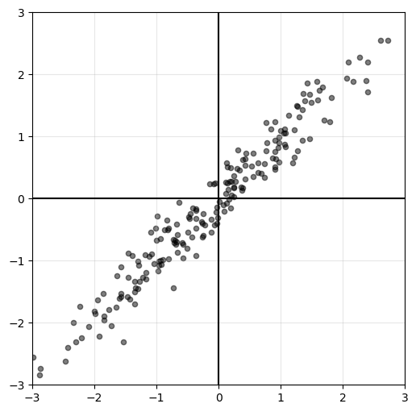

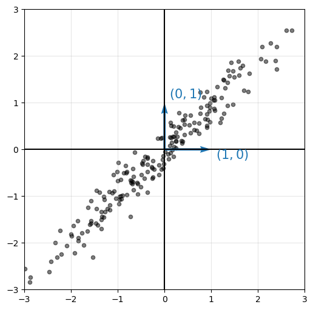

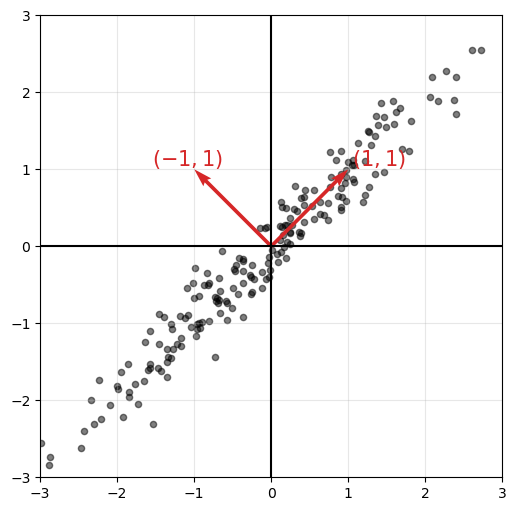

A tener en cuenta para PCA...

En este último caso, la base no es una base **ortonormal** (los vectores son ortogonales, pero su norma no es 1). La base es **ortogonal** ya que el producto escalar de sus vectores es cero:

$$(1, 1) \cdot (-1, 1) = 1 \cdot (-1) + 1 \cdot 1 = -1 + 1 = 0$$

Podemos normalizarla dividiendo cada vector por su norma:

$$\hat{l}_1 = \frac{1}{\sqrt{2}}(1, 1)$$ $$\hat{l}_2 = \frac{1}{\sqrt{2}}(-1, 1)$$

y llamar a esta nueva base $\hat{L}$, que es una base **ortonormal**:

$$\hat{L} = \{\hat{l}_1, \hat{l}_2\}$$

Ahora queremos construir una matriz que nos permita cambiar las coordenadas de un vector expresado en la base canónica $\hat{E}$ a esta nueva base ortonormal $\hat{L}$. Para ello, necesitamos encontrar la matriz de cambio de base $M_{\hat{E} \to \hat{L}}$ que nos permita expresar cualquier vector en la base $\hat{L}$ a partir de sus coordenadas en la base $\hat{E}$:

$$ M_{\hat{E} \to \hat{L}} \cdot [v]_{\hat{E}} = [v]_{\hat{L}} $$

$M_{\hat{E} \to \hat{L}}$ está formada por los vectores de la base $\hat{L}$ expresados en la base $\hat{E}$, es decir, cada columna de la matriz corresponde a un vector de la base $\hat{L}$:

$$M_{\hat{E} \to \hat{L}} = \begin{pmatrix} \hat{l}_1 & \hat{l}_2 \end{pmatrix} = \begin{pmatrix} \frac{1}{\sqrt{2}} & -\frac{1}{\sqrt{2}} \\ \frac{1}{\sqrt{2}} & \frac{1}{\sqrt{2}} \end{pmatrix}$$

Si queremos hacer lo inverso, necesitamos $M_{\hat{L} \to \hat{E}} = M_{\hat{E} \to \hat{L}}^{-1}$:

$$ M_{\hat{L} \to \hat{E}} \cdot [v]_{\hat{L}} = [v]_{\hat{E}} $$

Para ello, $M_{\hat{E} \to \hat{L}}$ tiene que ser inversible:

- Si los vectores de la base $\hat{L}$ son linealmente independientes, entonces $M_{\hat{E} \to \hat{L}}$ es inversible.
- Si además los vectores de la base $\hat{L}$ son ortonormales, entonces $M_{\hat{E} \to \hat{L}}$ es una matriz ortogonal, $det(M_{\hat{E} \to \hat{L}}) = \pm 1$, lo que significa que **su inversa es igual a su traspuesta**: $$ M_{\hat{E} \to \hat{L}}^{-1} = M_{\hat{E} \to \hat{L}}^T $$

Interpretar en función de transformaciones lineales...

[Repaso de Álgebra Lineal - 3Blue1Brown](https://www.youtube.com/playlist?list=PLZHQObOWTQDPD3MizzM2xVFitgF8hE_ab)

[figure not shown]